# RStudio Exercise 2: Analysis

## Reading the students2014 data into R

### R-code and output

You can find the code pressing the “code”-button on the right ->

```r
getwd()
```

```
## [1] "/Users/mirva/IODS-project"
```

```r
setwd("/Users/mirva/IODS-project/data")
learning2014 = read.csv("learning2014")
dim(learning2014)
```

```
## [1] 166   8
```

```r
str(learning2014)
```

```
## 'data.frame':    166 obs. of  8 variables:
##  $ X       : int  1 2 3 4 5 6 7 8 9 10 ...
##  $ gender  : Factor w/ 2 levels "F","M": 1 2 1 2 2 1 2 1 2 1 ...
##  $ age     : int  53 55 49 53 49 38 50 37 37 42 ...
##  $ attitude: int  37 31 25 35 37 38 35 29 38 21 ...
##  $ deep    : num  3.58 2.92 3.5 3.5 3.67 ...
##  $ stra    : num  3.38 2.75 3.62 3.12 3.62 ...
##  $ surf    : num  2.58 3.17 2.25 2.25 2.83 ...
##  $ points  : int  25 12 24 10 22 21 21 31 24 26 ...
```

This data is part of the data which Kimmo Vehkalahti has collected 3.12.2014 - 10.1.2015 on the course:

Johdatus yhteiskuntatilastotieteeseen, syksy 2014 (Introduction to Social Statistics, fall 2014 - in Finnish)

The data has 166 observations and 7 variables which are gender, age, attitude, deep, stra, surf and points

- gender has two options: M (Male), F (Female)
- age is (in years) derived from the date of birth
- attitude describes global attitude toward statistics
- deep, stra and suf are on the Likert-scale
- deep refers to deep learning and is the average score of the subsets Seeking Meaning, Relating Ideas and Use of Evidence
- stra refers to strategic learning and is the average score of the subsets Organized Studying and Time Management * surf refers to surface learning and is the average of the subsets Lack of Purpose, Unrelated Memorising and Syllabus-boundness
- points are the exam points of the course

## Graphical overview of the data

### R-code and plot

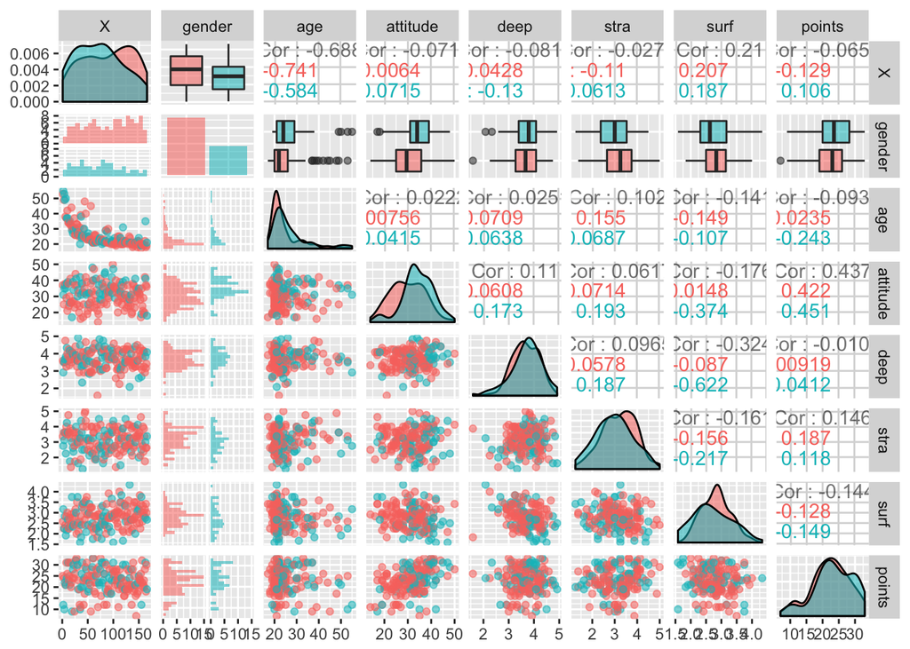

```r
library(ggplot2)
library(GGally)
overw <- ggpairs(learning2014, mapping = aes(col = gender, alpha = 0.3),
             lower = list(combo = wrap("facethist", bins = 20)))
overw
```

```r
summary(learning2014)
```

```
##        X          gender       age           attitude          deep
##  Min.   :  1.00   F:110   Min.   :17.00   Min.   :14.00   Min.   :1.583
##  1st Qu.: 42.25   M: 56   1st Qu.:21.00   1st Qu.:26.00   1st Qu.:3.333
##  Median : 83.50           Median :22.00   Median :32.00   Median :3.667
##  Mean   : 83.50           Mean   :25.51   Mean   :31.43   Mean   :3.680
##  3rd Qu.:124.75           3rd Qu.:27.00   3rd Qu.:37.00   3rd Qu.:4.083
##  Max.   :166.00           Max.   :55.00   Max.   :50.00   Max.   :4.917
##       stra            surf           points
##  Min.   :1.250   Min.   :1.583   Min.   : 7.00
##  1st Qu.:2.625   1st Qu.:2.417   1st Qu.:19.00
##  Median :3.188   Median :2.833   Median :23.00
##  Mean   :3.121   Mean   :2.787   Mean   :22.72
##  3rd Qu.:3.625   3rd Qu.:3.167   3rd Qu.:27.75
##  Max.   :5.000   Max.   :4.333   Max.   :33.00
```

The variables are all quite normally distributed except the age-variable where the min is 17, median 22 and max 55. Also the differences between men and women are quite small, allthough the distributions are not exactly equal. Biggest overall correlations are between attitude and points (r=.437) and deep and surf (negative, r=-.324), correspondingly smallest overall correlations are between deep and points (negative, r=-.0101), attitude and age (r=.0222) and deep and age (r.0251).

## Choosing the variables and fitting a regression model

y=“points”, x1=“attitude”, x2=“stra” and x3=“surf”

### Model 1

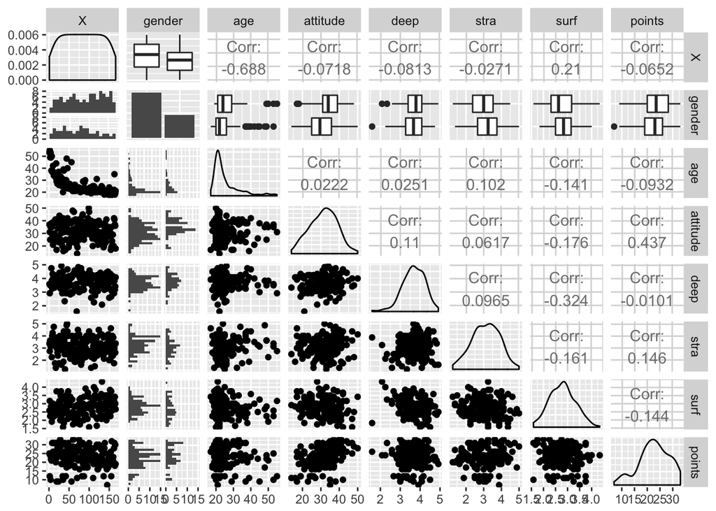

```r
ggpairs(learning2014, lower = list(combo = wrap("facethist", bins = 20)))
```

```r
regr1 <- lm(points ~ attitude + stra +surf, data = learning2014)
summary(regr1)
```

```
##
## Call:
## lm(formula = points ~ attitude + stra + surf, data = learning2014)
##
## Residuals:
##      Min       1Q   Median       3Q      Max
## -17.1550  -3.4346   0.5156   3.6401  10.8952
##
## Coefficients:
##             Estimate Std. Error t value Pr(>|t|)
## (Intercept) 11.01711    3.68375   2.991  0.00322 **
## attitude     0.33952    0.05741   5.913 1.93e-08 ***
## stra         0.85313    0.54159   1.575  0.11716
## surf        -0.58607    0.80138  -0.731  0.46563
## ---
## Signif. codes:  0 '***' 0.001 '**' 0.01 '*' 0.05 '.' 0.1 ' ' 1
##
## Residual standard error: 5.296 on 162 degrees of freedom
## Multiple R-squared:  0.2074, Adjusted R-squared:  0.1927
## F-statistic: 14.13 on 3 and 162 DF,  p-value: 3.156e-08
```

T-value of attitude (5.913) is statistically significant (p<.001) so the attitude-variable explains well the points-variable. T-values of stra (1.575) and surf(-0.731) aren´t significant in this model so I will remove the one with smaller t-value: the variable surf.

### Model 2

```r
regr2 <- lm(points ~ attitude + stra, data = learning2014)
summary(regr2)
```

```
##
## Call:
## lm(formula = points ~ attitude + stra, data = learning2014)
##
## Residuals:
##      Min       1Q   Median       3Q      Max
## -17.6436  -3.3113   0.5575   3.7928  10.9295
##
## Coefficients:
##             Estimate Std. Error t value Pr(>|t|)
## (Intercept)  8.97290    2.39591   3.745  0.00025 ***
## attitude     0.34658    0.05652   6.132 6.31e-09 ***
## stra         0.91365    0.53447   1.709  0.08927 .
## ---
## Signif. codes:  0 '***' 0.001 '**' 0.01 '*' 0.05 '.' 0.1 ' ' 1
##
## Residual standard error: 5.289 on 163 degrees of freedom
## Multiple R-squared:  0.2048, Adjusted R-squared:  0.1951
## F-statistic: 20.99 on 2 and 163 DF,  p-value: 7.734e-09
```

The p-value of the variable stra (p=.08927) remains still >.05 so i will also remove it from the model.